# *Kaggle Camera Dataset Exploration*

## *Preliminary Wrangling*

*This document explores a dataset containing cameras and their features for approximately **1038** models.*

*Looking at the descriptive statistics of all numeric variables of the data, certain features appear to have zeroes. Since cameras can have no **Max resolution**, **low resolution**, **Effective pixels**, **Zoom wide (W)**, **Zoom tele (T)**, **Normal focus range**, **Macro focus range**, **Storage included**, **Weight (inc. batteries)**, and **Dimensions**. These values must be addressed as missing values!*

*There are missing values in the dataset, which should be filled in with their peers average values.*

*No duplicated entries exist in the data.*

## *The dataset structure:*

*The data consists of **1038** entries and **13** features, which are: `Model`, `Release date`, `Max resolution`, `Low resolution`, `Effective pixels`, `Zoom wide (W)`, `Zoom tele (T)`, `Normal focus range`, `Macro focus range`, `Storage included`, `Weight (inc. batteries)`, `Dimensions`, and `Price`. Most variables are numeric in nature, except for the **Model** variable, which is a categorical one, and **Release date**, which is more datetime than integer.*

## *The main feature of interest in the data:*

*I'm interested in figuring out how **Release date** correlates to the different features in the data, meaning how the camera variables change over time.*

## *The features in the dataset that, in my opinion, will help support the investigation into the feature of interest:*

*Maybe we should consider features like: **Effective pixels**, **Zoom wide (W)**, **Zoom tele (T)**, **Normal focus range**, **Macro focus range**, **Storage included**, **Weight (inc. batteries)**, **Dimensions**, and **Price** will provide useful insights of how cameras have changed over time and what improved in these cameras exactly.*

## *Univariate Exploration*

*In this section, we'll investigate distributions of individual variables.*

## *1. Distribution of Release Date*

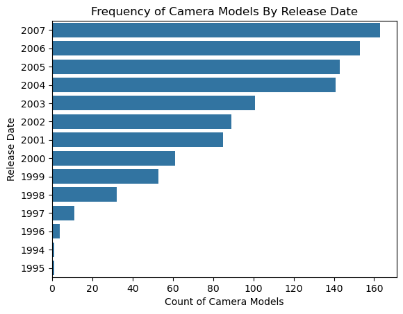

*The **Release date** Pareto chart shows that there are more camera models in recent years, meaning that more models are added to the market each year. As time goes by, there will definitely be more camera models.*

## *2. Distribution of Effective Pixels*

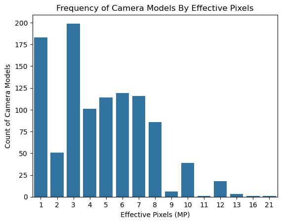

*The **Effective Pixels** bar chart shows more frequency of models for cameras with fewer effective pixels and a lower frequency for models with higher effective pixels.*

## *3. Distribution of Zoom Wide*

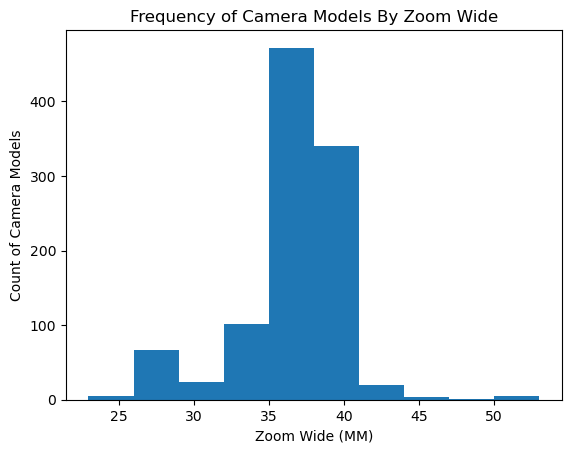

*The **Zoom Wide** histogram shows that most camera models in the data have between **30** and **40** millimeters of focal length range, which is a very narrow focal length range. Most of these cameras offer only minimal zoom. They are considered more of a short-range zoom or **Standard** lens rather than a versatile zoom for multiple scenarios.*

## *4. Distribution of Zoom Tele*

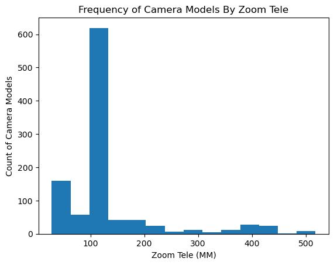

*The **Zoom Tele** histogram shows that most cameras are ranged between **100** and **200** milimeters lens, which means they share a narrow field of veiw, often isolating subjects.*

## *5. Distribution of Normal Focus Range*

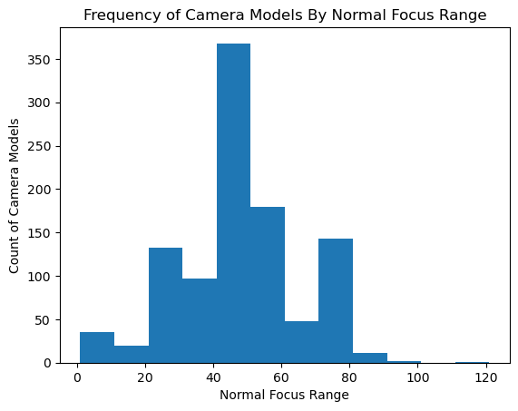

*The **Normal focus range** histogram multiple peaks suggest that there are different categories of cameras with a certain normal focus range. The most frequent focus ranges are **50**, **60**, **80**, **30**, and **40** in that order.*

## *6. Distribution of Macro Focus Range*

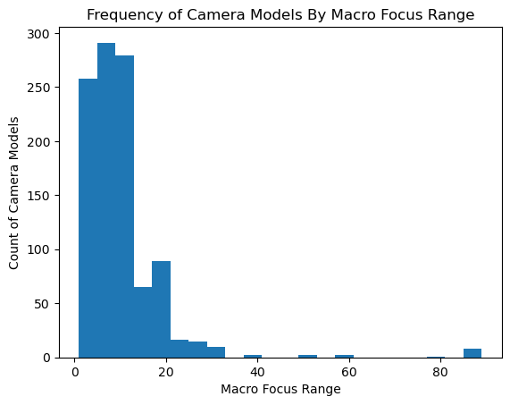

*The **Macro Focus Range** histogram is skewed to the right, which indicates that cameras with higher macro focus ranges are less frequent. The majority of macro focus ranges are between **1** and **20**.*

## *7. Distribution of Cameras Storage*

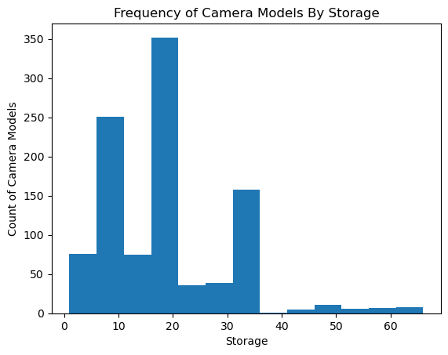

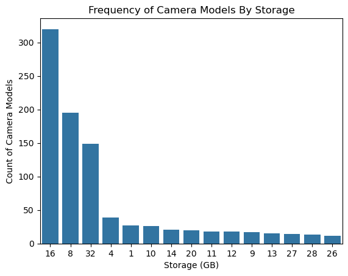

*The **Storage included** histogram shows a much higher frequency for cameras with lower storage capacity, while the Pareto chart shows the three main peaks. The highest three storage capacities are: **16**, **8**, and **32** GB in that specific order.*

## *8. Distribution of Cameras Weight*

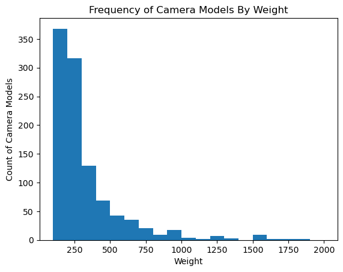

*The **Weight (inc. batteries)** histogram is skewed to the right. Relatively heavier cameras are less frequent, while light cameras are very common.*

## *9. Distribution of Cameras Dimensions*

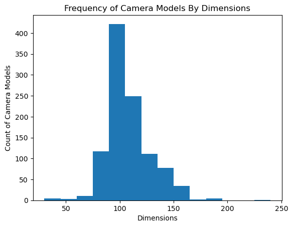

*The **Dimensions** histogram looks normally distributed around **100** where cameras are most frequent, while the number of camera decrease drastically for higher or lower dimensions. Looks like medium-sized cameras are more preferable.*

## *10. Distribution of Cameras Price*

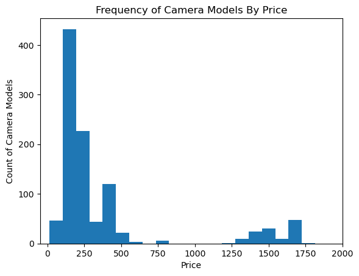

*The **Price** histogram is skewed to the right. There are way more camera models with lower prices than high-priced cameras.*

## *Conclusion of The Univariate Exploration:*

*The **Release date** Pareto chart showed that camera models grew in number in recent years. The **Effective Pixels** bar chart revealed that cameras with fewer effective pixels are much more frequent. In the **Zoom Wide** histogram, most cameras have short-rage zoom capabilities or **Standard** lens. The **Zoom Tele** histogram showed that most cameras share a narrow field of view. The **Normal Focus Range** mutiple-peaked histogram showed that there are different camera categories with different normal focus ranges. The **Macro Focus Range** histogram was skewed to the right, which means higher macro focus range cameras are less frequent. Similarily, the **Storage included** histogram was skewed to the right, which demonstrated that lower storage capacity is more frequent. Also, the **Weight (inc. batteries)** histogram was skewed to the right, which indicated that lighter cameras are more frequent. The **Dimensions** histogram is nearly bell-shaped, which revealed that medium-sized cameras are the most frequent regarding size. Finaly, the **Price** histogram was again skewed to the right, which means that expensive cameras are less frequent and vice versa.*

## *Bivariate Exploration*

*In this section, we'll investigate relationships between pairs of variables in our data.*

## *1. Effective Pixels Vs. Zoom Capabilities*

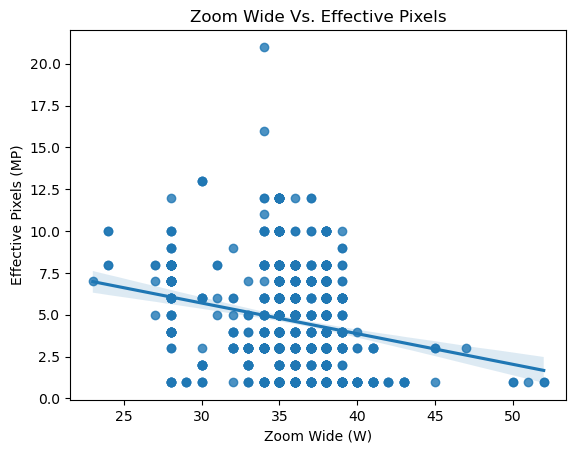

*The scatterplot shows a negative correlation between the **Effective pixels** of cameras and their **Zoom wide** capacities. Often, cameras with fewer effective pixels have higher zoom wide capacity.*

## *2. Weight Vs. Dimensions*

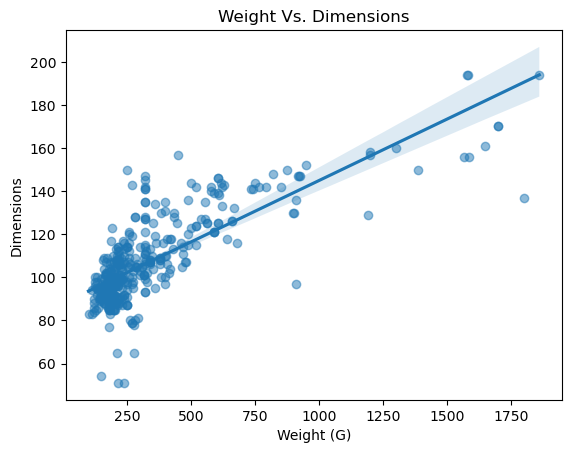

*The scatterplot shows that **Weight (inc. batteries)** and **Dimensions** are positively correlated. When the size of cameras increases, the weight also increases. Makes perfect sense! Most cameras have medium dimensions and low weight (less than 1 kilogram).*

## *3. Weight Vs. Price*

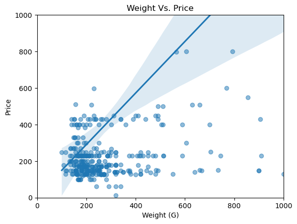

*The scatterplot shows the positive correlation between the **Price** of a camera and **Weight (inc. batteries)** or **Dimensions** for that matter since the last two features are also positively correlated.*

## *4. Weight Vs. Storage*

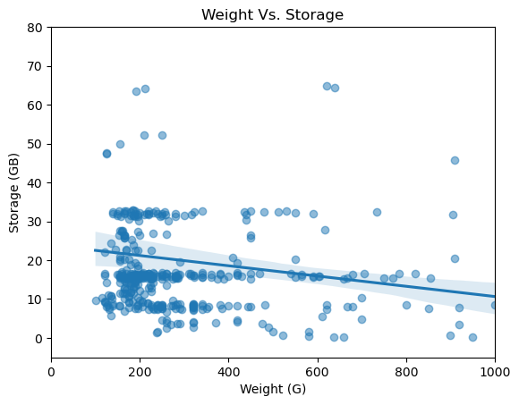

*According to the scatterplot, the **Weight (inc. batteries)** and **Storage included** are negatively correlated, which means heavier and bigger (**Dimensions**) cameras don't necessarily have higher storage capacity. Most cameras are light in weight and low in storage capacity.*

## *5. Release Date Vs. Price*

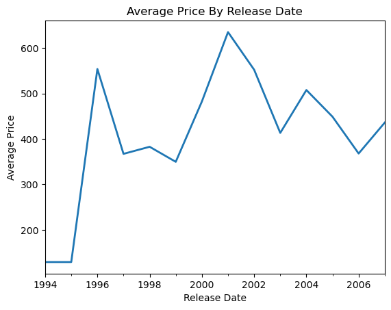

## *6. Release Date Vs. Weight*

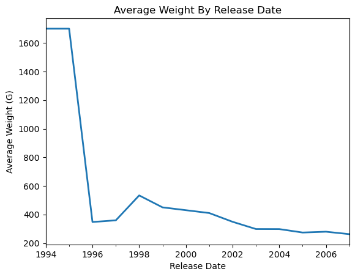

*The line plot of the average **Weight (inc. batteries)** by the **Release date** shows the downward general trend of the relationship between these two variables. New models of cameras tend to be relatively lighter than the older models. The most significant drop in camera weights was between **1994** and **1996**.*

## *7. Release Date Vs. Storage*

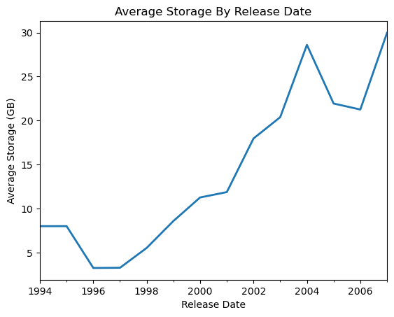

*The line plot of the average **Storage included** by the **Release date** shows clearly the upward positive trend of the correlation between these two variables. Newer cameras can store more images.*

## *Conclusion of The Bivariate Exploration:*

*The **Effective pixels Vs. Zoom wide** scatterplot shows a negative correlation between the effective pixels of cameras and their zoom wide capabilities. Often, cameras with fewer effective pixels have higher wide zoom capacity. The **Weight (inc. batteries) Vs. Dimensions** scatterplot shows that the weight and dimensions are positively correlated. When the size of cameras increases, the weight also increases. The **Price Vs. Weight (inc. batteries)** scatterplot shows the positive correlation between the price of cameras and their weight or size, for that matter, since these two features are also positively correlated. According to the **Weight (inc. batteries) Vs. Storage included** scatterplot, the weight and storage are negatively correlated, which means heavier and bigger cameras don't necessarily have higher storage capacity. The line plot of the average **Price** by the **Release date** shows fluctuations in price over time, but generally a lower trend in recent years. The line plot of the average **Weight (inc. batteries)** by the **Release date** shows the downward general trend of the relationship between these two variables. Newer models of cameras tend to be relatively lighter than the older models. The line plot of the average **Storage included** by the **Release date** shows clearly the upward positive trend of the correlation between these two variables. Newer cameras can store more images.*

## *Multivariate Exploration*

*In this section, we'll create plots of three or more variables to investigate our data even further.*

## *1. Weight Vs. Dimensions By Release Date*

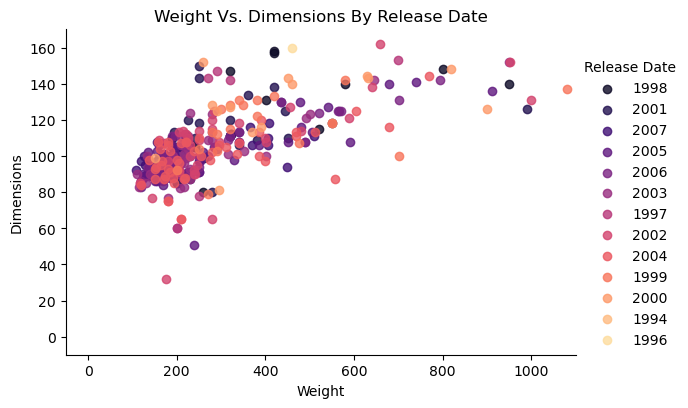

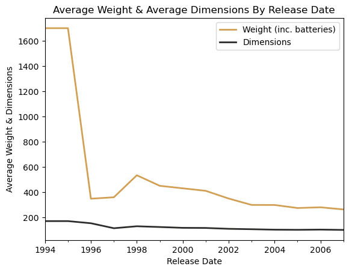

*The line plot makes it clear as time goes by the weight and size of cameras tend to decrease on average.*

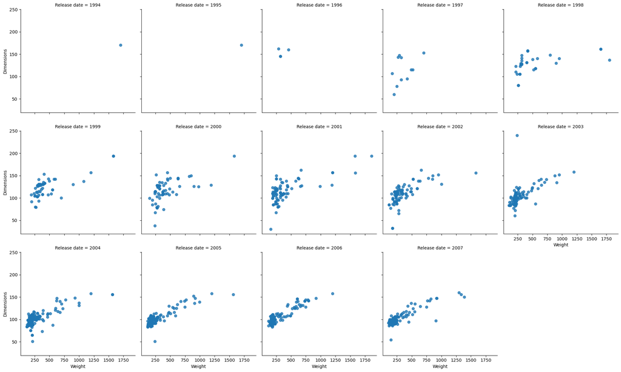

## *2. Weight Vs. Price By Release Date*

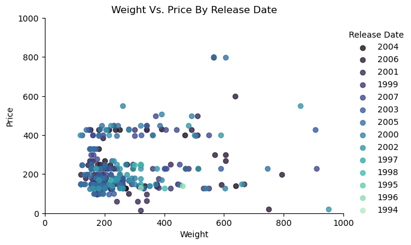

*Darker colored points are much more frequent which means these models are released recently and are clustered at the lower left of the plot where both variables: price and weight are relatively lower.*

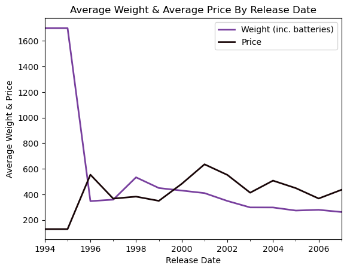

*The line plot shows that on average cameras weight and price decrease in recent years. The weight line decreases noticebly while the price line seems somehow steady.*

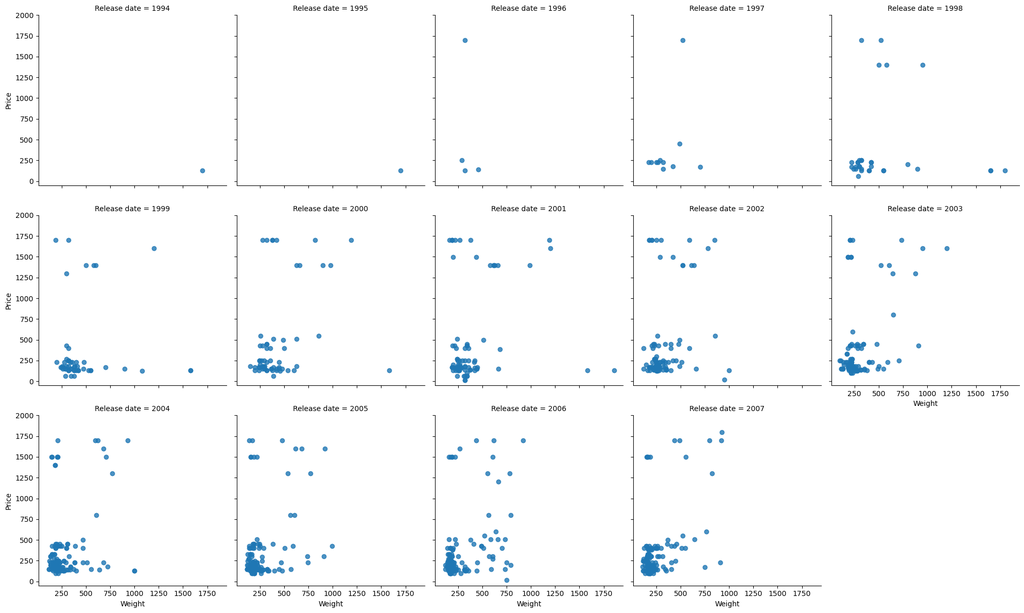

*The abov facet grid shows that over the years, new cameras are lighter and hence smaller. The **Price** also tends to decrease, as points tend to cluster at low **Weight (inc. batteries)** and **Price** over time, which concurs with the bivariate visualizations result. We can see the same pattern in the scatterplot with color encodings as points with darker colors thar are released in recent years cluster at the lower left corner of the plot. The general frequency in the grid seems to be higher in recent years in overall.*

## *3. Weight Vs. Storage By Release Date*

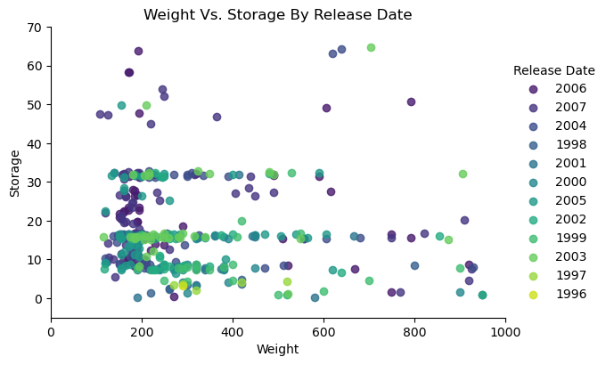

*The darker color of points in the scatterplot indicates that cameras released recently are much more frequent. These points cluster at low weight and low storage.*

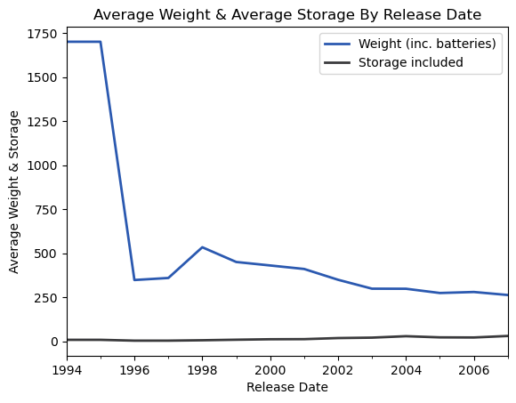

*In the line plot, the average weight is obviously decreasing with time, while the average storage seems to slighly increasing. Maybe because the storage units are in gigabytes. Slight increase in gigabytes makes a huge difference as one gigabyte can store many images.*

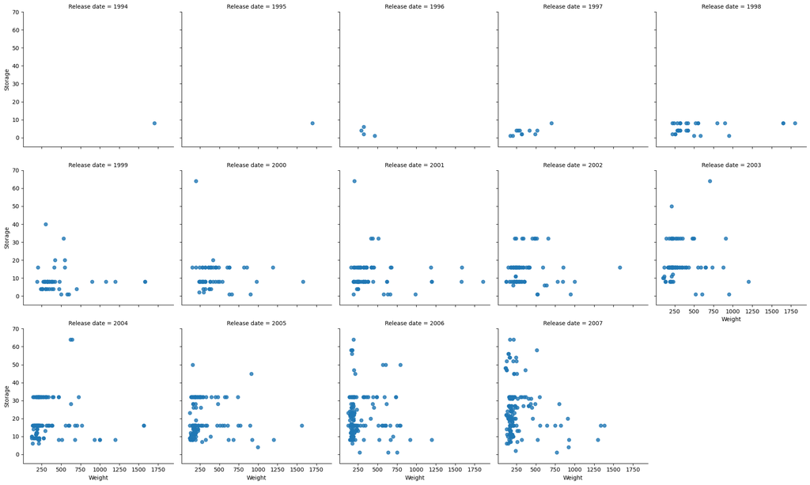

*The above facet grid shows that over the years, cameras still get lighter, but the storage capacity tends to increase, as points cluster at low **Weight (inc. batteries)** but higher **Storage included** over the years, which is the same as the bivariate conclusions. The same trend can be detected in the scatterplot with color encodings as points with darker colors that is released in recent years cluster at the upper left corner of the plot. The general frequecy seems to be increasing in recent years, which is the same trend as the previous two grids.*

## *Conclusion of The Multivariate Exploration:*

*In this section, I wanted to understand more about the **Release date** feature, so I used non-positional encodings and faceting to visualize this feature. I replotted three scatterplots again with color encodings for the Release date feature. The multivariate plots concurred with the insights, we learned from the univariate and bivariate visualizations. The size and weight of cameras tend to decrease simultaneously, as points tend to cluster more and more at low **Weight (inc. batteries)** and **Dimensions** over the years in the first facet grid which concurred the positive correlation between cameras' weight and size. When **Release date** increases, both features decrease as cameras get lighter and hence smaller. The **Price** tends to decrease, as points cluster at low **Weight (inc. batteries)** and **Price** over the years in the second facet grid. The facet grid also reconfirmed the positive correlation between cameras's weight and price and that both these features decrease when **Release date** increases. As cameras get lighter, the storage capacity tends to increase, as points cluster at low **Weight (inc. batteries)** but higher **Storage included** over the years. The last facet grid also reconfirmed the negative relationship between the cameras' weight and their storage capacity. When **Release date** increases, the **Storage included** feature increases, but the **Weight (inc. batteries)** decreases.*